# PRA2 - Limpieza y pre-procesado del dataset

Autor: Christopher Irvin Ballon Peralta

# 1 Elección del conjunto de datos

Nos decidimos por elegir un juego de datos de kaggle

https://www.kaggle.com/marialuiza07/santander-product-recomendation/version/1?select=train_ver2.csv

Buscando un poco, el juego de datos fue originalmente propuesto en un concurso del Banco Santander de España, consistia en clasificar la base de datos de clientes con el fin de ofrecerles el producto que tenga mas probabilidad de ser contratado por el cliente para una campaña de productos financieros en navidad.

# 2 Exploración del conjunto de datos

Primero importamos el juego de datos y mostramos las dimensiones

```r
if (!require(readr)) install.packages(plyr)
require(readr)
df <- read_csv("train_ver2.csv")
print(dim(df))
```

```
## [1] 13647309       48
```

Para realizar el tratamiento de datos seleccionamos una muestra de los datos totales, luego generalizamos el proceso con todo el dataset.

```r
if (!require(dplyr)) install.packages(plyr)
require(dplyr)
library(dplyr)
df <- sample_frac(df, 0.08)
```

Realizamos una primera visualización de las columnas

```r
head(df)
```

```
## # A tibble: 6 × 48
##   fecha_dato ncodpers ind_emple…¹ pais_…² sexo    age fecha_alta ind_n…³ antig…⁴
##   <date>        <dbl> <chr>       <chr>   <chr> <dbl> <date>       <dbl>   <dbl>
## 1 2015-11-28   457091 N           ES      V        77 2004-02-02       0     141
## 2 2016-03-28  1120591 N           ES      H        13 2013-02-07       0      37
## 3 2016-03-28   527690 N           ES      V        48 2005-04-11       0     131
## 4 2015-10-28  1492545 N           ES      H        20 2015-10-28       1       0
## 5 2016-05-28  1464032 N           ES      H        44 2015-09-29       0       8
## 6 2015-09-28   312177 N           ES      V        69 2001-12-31       0     165
## # … with 39 more variables: indrel <dbl>, ult_fec_cli_1t <date>,
## #   indrel_1mes <dbl>, tiprel_1mes <chr>, indresi <chr>, indext <chr>,
## #   conyuemp <lgl>, canal_entrada <chr>, indfall <chr>, tipodom <dbl>,
## #   cod_prov <dbl>, nomprov <chr>, ind_actividad_cliente <dbl>, renta <dbl>,
## #   segmento <chr>, ind_ahor_fin_ult1 <dbl>, ind_aval_fin_ult1 <dbl>,
## #   ind_cco_fin_ult1 <dbl>, ind_cder_fin_ult1 <dbl>, ind_cno_fin_ult1 <dbl>,
## #   ind_ctju_fin_ult1 <dbl>, ind_ctma_fin_ult1 <dbl>, …
```

## 2.1 Analisis de caracteristicas:

Mostramos la descripción de las columnas, información adjunta al dataset.

**fecha_dato** Fecha que se crea el registro

**ncodpers** Codigo del cliente

**ind_empleado** Indice de empleado: A activo, B ex empleado, F filial, N no empleado, P pasivo

**pais_residencia** Pais de residencia del cliente

**sexo** Genero del cliente

**age** Edad

**fecha_alta** Fecha en que el cliente contrato su primer producto con el banco

**ind_nuevo** Indice de nuevo cliente (1 si se registró en los ultimos 6 meses)

**antiguedad** antiguedad del cliente (en meses)

**indrel** 1 (Cliente principal / primario), 99 (Cliente principal al inicio del mes, pero no al final del mes)

**ult_fec_cli_1t** Ultima fecha como cliente principal (si no estuvo al final del mes)

**indrel_1mes** Tipo de cliente al comienzo de mes, 1 (Cliente principal / primario), 2 (Mancomunado),P (Potencial),3 (anteriormente primario), 4(anteriormente mancomunado)

**tiprel_1mes** Tipo de relación del cliente a principio de mes, A (activo), I (inactivo), P (anteriormente cliente),R (Potencial)

**indresi** Indice de residencia (S (Si) or N (No) el pais de residencia es el mismo de la locación del banco)

**indext** Indice de extrangero (S (Si) or N (No) el pais de nacimiento del cliente es el mismo que la localidad del banco)

**conyuemp** Indice de esposo. 1 si el cliente es esposo (a) de un trabajador

**canal_entrada** Canal por el cual el cliente fue ingresado

**indfall** Indice de fallecido. N/S

**tipodom** Tipo de domicilio. 1, Dirección primaria

**cod_prov** codigo de provincia (Domicilio del cliente)

**nomprov** Nombre de provincia

**ind_actividad_cliente** Indice de actividad (1, cliente activo; 0, cliente inactivo)

**renta** Ingreso bruto por hogar

**segmento** segmentación: 01 - VIP, 02 - Individuos 03 - Graduado universitario

**ind_ahor_fin_ult1** Cuenta de ahorros

**ind_aval_fin_ult1** Garantia

**ind_cco_fin_ult1** Cuenta corriente

**ind_cder_fin_ult1** Cuenta derivada

**ind_cno_fin_ult1** Cuenta de nomina de sueldos

**ind_ctju_fin_ult1** Cuenta junior

**ind_ctma_fin_ult1** Cuenta Más particular

**ind_ctop_fin_ult1** CUenta particular

**ind_ctpp_fin_ult1** Cuenta Particular Plus

**ind_deco_fin_ult1** Deposito a corto plazo

**ind_deme_fin_ult1** Deposito a mediano plazo

**ind_dela_fin_ult1** Deposito a largo plazo

**ind_ecue_fin_ult1** Cuenta electronica

**ind_fond_fin_ult1** Cuenta de fondos

**ind_hip_fin_ult1** Prestamo hipotecario

**ind_plan_fin_ult1** Pensión

**ind_pres_fin_ult1** Prestamo

**ind_reca_fin_ult1** Cuenta de impuestos

**ind_tjcr_fin_ult1** Tarjeta de credito

**ind_valo_fin_ult1** Seguro

**ind_viv_fin_ult1** Cuenta domestica

**ind_nomina_ult1** nomina de sueldo

**ind_nom_pens_ult1** Pensiones

**ind_recibo_ult1** Debito directo

Realizamos una primera inspección de las caracteristicas

```r
summary(df)
```

```
##    fecha_dato            ncodpers       ind_empleado       pais_residencia
##  Min.   :2015-01-28   Min.   :  15892   Length:1091785     Length:1091785
##  1st Qu.:2015-06-28   1st Qu.: 452932   Class :character   Class :character
##  Median :2015-10-28   Median : 931716   Mode  :character   Mode  :character
##  Mean   :2015-10-20   Mean   : 835045
##  3rd Qu.:2016-02-28   3rd Qu.:1199248
##  Max.   :2016-05-28   Max.   :1553673
##
##      sexo                age          fecha_alta           ind_nuevo
##  Length:1091785     Min.   :  2.0   Min.   :1995-01-16   Min.   :0.0000
##  Class :character   1st Qu.: 24.0   1st Qu.:2004-04-26   1st Qu.:0.0000
##  Mode  :character   Median : 39.0   Median :2011-09-01   Median :0.0000
##                     Mean   : 40.2   Mean   :2009-02-09   Mean   :0.0595
##                     3rd Qu.: 50.0   3rd Qu.:2013-10-18   3rd Qu.:0.0000
##                     Max.   :117.0   Max.   :2016-05-31   Max.   :1.0000
##                     NA's   :2210    NA's   :2210         NA's   :2210
##    antiguedad            indrel       ult_fec_cli_1t        indrel_1mes
##  Min.   :-999999.0   Min.   : 1.000   Min.   :2015-07-01   Min.   :1.000
##  1st Qu.:     23.0   1st Qu.: 1.000   1st Qu.:2015-08-07   1st Qu.:1.000
##  Median :     50.0   Median : 1.000   Median :2015-11-23   Median :1.000
##  Mean   :     75.7   Mean   : 1.175   Mean   :2015-11-22   Mean   :1.001
##  3rd Qu.:    135.0   3rd Qu.: 1.000   3rd Qu.:2016-02-15   3rd Qu.:1.000
##  Max.   :    256.0   Max.   :99.000   Max.   :2016-05-30   Max.   :4.000
##  NA's   :2210        NA's   :2210     NA's   :1089845      NA's   :12060
##  tiprel_1mes          indresi             indext          conyuemp
##  Length:1091785     Length:1091785     Length:1091785     Mode:logical
##  Class :character   Class :character   Class :character   NA's:1091785
##  Mode  :character   Mode  :character   Mode  :character
##
##
##
##
##  canal_entrada        indfall             tipodom        cod_prov
##  Length:1091785     Length:1091785     Min.   :1      Min.   : 1.00
##  Class :character   Class :character   1st Qu.:1      1st Qu.:15.00
##  Mode  :character   Mode  :character   Median :1      Median :28.00
##                                        Mean   :1      Mean   :26.58
##                                        3rd Qu.:1      3rd Qu.:35.00
##                                        Max.   :1      Max.   :52.00
##                                        NA's   :2211   NA's   :7449
```

[output cut: 41 more lines]

```
##  Min.   :0.000000   Min.   :0.00000   Min.   :0.00000   Min.   :0.00000
##  1st Qu.:0.000000   1st Qu.:0.00000   1st Qu.:0.00000   1st Qu.:0.00000
##  Median :0.000000   Median :0.00000   Median :0.00000   Median :0.00000
##  Mean   :0.002675   Mean   :0.05262   Mean   :0.04458   Mean   :0.02557
##  3rd Qu.:0.000000   3rd Qu.:0.00000   3rd Qu.:0.00000   3rd Qu.:0.00000
##  Max.   :1.000000   Max.   :1.00000   Max.   :1.00000   Max.   :1.00000
##
##  ind_viv_fin_ult1   ind_nomina_ult1  ind_nom_pens_ult1 ind_recibo_ult1
##  Min.   :0.000000   Min.   :0.0000   Min.   :0.0000    Min.   :0.0000
##  1st Qu.:0.000000   1st Qu.:0.0000   1st Qu.:0.0000    1st Qu.:0.0000
##  Median :0.000000   Median :0.0000   Median :0.0000    Median :0.0000
##  Mean   :0.003841   Mean   :0.0548   Mean   :0.0595    Mean   :0.1282
##  3rd Qu.:0.000000   3rd Qu.:0.0000   3rd Qu.:0.0000    3rd Qu.:0.0000
##  Max.   :1.000000   Max.   :1.0000   Max.   :1.0000    Max.   :1.0000
##                     NA's   :1287     NA's   :1287
```

```r
df <- df[ !duplicated(df[, c("ncodpers", "fecha_dato")], fromLast=T),]
```

De un primer analisis observamos que varias columnas tienen valores nulos y que las ultimas 24 columnas perteneces a los productos que tienen contratados cada cliente, a partir de ello podemos indicar que cada cliente solo cuenta con una unidad de cada producto como maximo, lo cual puede ser util para codificar esta información mas adelante en el preprocesado de datos, por ejemplo expresar en formato binario (0s y 1s)

Para un analisis más especifico obtenemos el porcentaje de nulos de cada columna

```r
colMeans(is.na(df))
```

```
##            fecha_dato              ncodpers          ind_empleado
##           0.000000000           0.000000000           0.002024208
##       pais_residencia                  sexo                   age
##           0.002024208           0.002029704           0.002024208
##            fecha_alta             ind_nuevo            antiguedad
##           0.002024208           0.002024208           0.002024208
##                indrel        ult_fec_cli_1t           indrel_1mes
##           0.002024208           0.998223093           0.011046131
##           tiprel_1mes               indresi                indext
##           0.010979268           0.002024208           0.002024208
##              conyuemp         canal_entrada               indfall
##           1.000000000           0.013607991           0.002024208
##               tipodom              cod_prov               nomprov
##           0.002025124           0.006822772           0.006822772
## ind_actividad_cliente                 renta              segmento
##           0.002024208           0.205070595           0.013841553
##     ind_ahor_fin_ult1     ind_aval_fin_ult1      ind_cco_fin_ult1
##           0.000000000           0.000000000           0.000000000
##     ind_cder_fin_ult1      ind_cno_fin_ult1     ind_ctju_fin_ult1
##           0.000000000           0.000000000           0.000000000
##     ind_ctma_fin_ult1     ind_ctop_fin_ult1     ind_ctpp_fin_ult1
##           0.000000000           0.000000000           0.000000000
##     ind_deco_fin_ult1     ind_deme_fin_ult1     ind_dela_fin_ult1
##           0.000000000           0.000000000           0.000000000
##     ind_ecue_fin_ult1     ind_fond_fin_ult1      ind_hip_fin_ult1
##           0.000000000           0.000000000           0.000000000
##     ind_plan_fin_ult1     ind_pres_fin_ult1     ind_reca_fin_ult1
##           0.000000000           0.000000000           0.000000000
##     ind_tjcr_fin_ult1     ind_valo_fin_ult1      ind_viv_fin_ult1
##           0.000000000           0.000000000           0.000000000
##       ind_nomina_ult1     ind_nom_pens_ult1       ind_recibo_ult1
##           0.001178804           0.001178804           0.000000000
```

```r
if (!require(plyr)) install.packages(plyr)
```

```r
require(plyr)
library(plyr)
df$ind_nomina_ult1 <- mapvalues(df$ind_nomina_ult1, from=c(NA), to=c(0))
df$ind_nom_pens_ult1 <- mapvalues(df$ind_nom_pens_ult1, from=c(NA), to=c(0))
```

vemos que la columna *counyuemp* esta completamente conformada de valores nulos, por lo que podemos omitirla en el analisis, esto puede indicar que ningun cliente es conyugue de un trabajador, o no se ingresó esta información.

De forma parecida ocurre con la columna *ult_fec_cli_1t*, se cuenta con menos del 1% de datos ingresados, por esto y al estar imposibilitados de completar o estimar los datos faltantes para esta columna, la omitimos.

En todos los demas casos creeemos que será posible tratar los valores nulos, siendo el mas alto en porcentaje de nulos: *Renta*, que indica el ingreso bruto del hogar del cliente. (20% aproximadamente)

```r
drops <- c("conyuemp","ult_fec_cli_1t")
df <- df[, !(names(df) %in% drops)]
```

# 3 Preprocesado y gestión de características

Comenzaremos gestionando la variable *ind_empleado*, esta indica si el cliente es trabajador del banco, podemos imputar los valores nulos con el valor N, (no es empleado) y verificamos tambien la integridad del resto de valores.

```r
print(unique(df[c("ind_empleado")]))
```

```
## # A tibble: 6 × 1
##   ind_empleado
##   <chr>
## 1 N
## 2 <NA>
## 3 B
## 4 A
## 5 F
## 6 S
```

Verificamos los unicos valores en la columna, reetiquetamos S a P (pasivo, unica categoria faltante) y los valores nulos a N (No empleado)

```r
df$ind_empleado <- mapvalues(df$ind_empleado, from=c(NA,"S"), to=c("N", "P"))
print(unique(df[c("ind_empleado")]))
```

```
## # A tibble: 5 × 1
##   ind_empleado
##   <chr>
## 1 N
## 2 B
## 3 A
## 4 F
## 5 P
```

Visualizamos los valores de *pais_residencia*

```r
print(unique(df[c("pais_residencia")]))
```

```
## # A tibble: 109 × 1
##    pais_residencia
##    <chr>
##  1 ES
##  2 <NA>
##  3 CH
##  4 VE
##  5 IT
##  6 CO
##  7 AR
##  8 DE
##  9 DO
## 10 FR
## # … with 99 more rows
```

Imputamos los valores nulos a D. (Desconocido)

```r
df$pais_residencia <- mapvalues(df$pais_residencia, from=c(NA), to=c("D"))
```

```r
print(unique(df[c("sexo")]))
```

```
## # A tibble: 3 × 1
##   sexo
##   <chr>
## 1 V
## 2 H
## 3 <NA>
```

Reetiquetamos los valores nulos a D (desconocido)

```r
df$sexo <- mapvalues(df$sexo, from=c(NA), to=c("D"))
```

Realizamos un grafico de barras para la variable *age*:

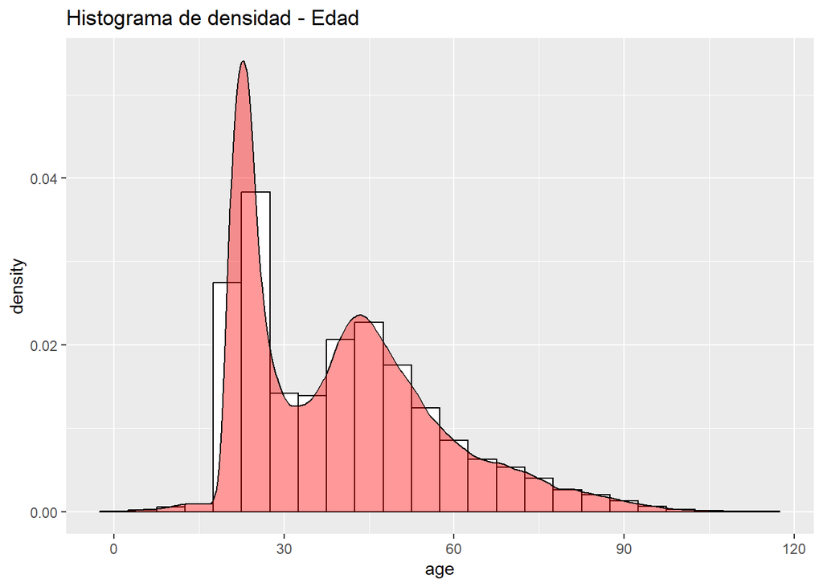

```r
require(ggplot2)
if (!require(ggplot2)) install.packages(ggplot2)
library(ggplot2)

ggplot(df, aes(x = age)) +
  geom_vline(aes(xintercept = mean(age)), color = "blue",
             linetype = "dashed", size = 1.5) +
  geom_histogram(binwidth = 5, aes(y = ..density..),
                 color = "black", fill = "white") +
  geom_density(alpha = 0.4, fill = "red") +
  labs(title = "Histograma de densidad - Edad")
```

Procederemos a imputar los valores faltantes con la media. (los datos faltantes conforman solo el 0.2%)

```r
df$age <- mapvalues(df$age, from=c(NA), to=c(mean(df$age)))
```

De manera similar con las variables *ind_nuevo*, imputaremos los valores nulos a 0 (no se registró en los ultimos 6 meses) y *antiguedad*, imputaremos los valores nulos con la media, ya que los valores nulos representan el 0.2% del total

```r
df$ind_nuevo <- mapvalues(df$ind_nuevo, from=c(NA), to=c(0))
df$antiguedad <- mapvalues(df$antiguedad, from=c(NA), to=c(mean(df$antiguedad)))
```

Para tratar *indresi* y *indext* realizamos un grafico de barras:

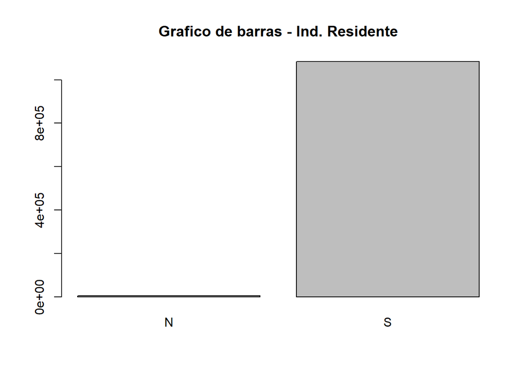

```r
counts <- table(df$indresi)
barplot(counts, main = "Grafico de barras - Ind. Residente")
```

Observamos del grafico de barras de la variable indice de residente, (si el cliente reside en la misma localidad del banco) un porcentaje extremandamente bajo no es residente, por ello podemos desestimar las variables *indresi* y *indext* ya que se cuenta con columnas con mas información como codigo de provincia y pais de procedencia.

```r
drops <- c("indresi","indext")
df <- df[, !(names(df) %in% drops)]
```

De manera similar, realizamos un grafico de barras para la variable *ind_nuevo*

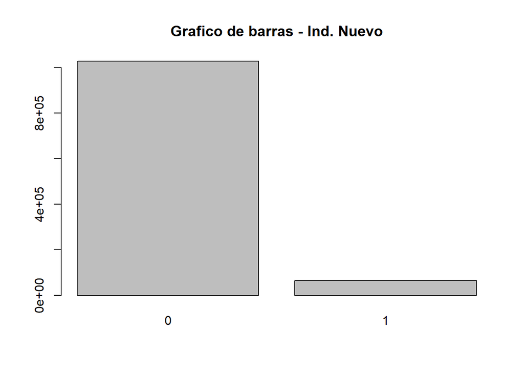

```r
counts <- table(df$ind_nuevo)
barplot(counts, main = "Grafico de barras - Ind. Nuevo")
```

Vemos que esta variable también aporta muy poca información (el numero de clientes ingresados en los ultimos 6 meses no se significativo) y queda mejor expresada dentro de la variable *antiguedad*

```r
drops <- c("ind_nuevo")
df <- df[, !(names(df) %in% drops)]
```

Similarmente con al variable *indrel*:

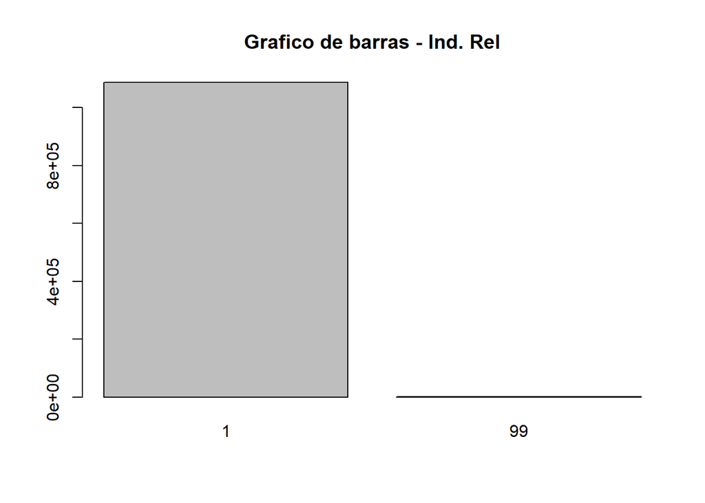

```r
counts <- table(df$indrel)
barplot(counts, main = "Grafico de barras - Ind. Rel")
```

Esta variable tambien no aporta información significativa ya que casi todos los clientes son principales.

```r
drops <- c("indrel", "indrel_1mes", "tiprel_1mes")
df <- df[, !(names(df) %in% drops)]
```

Realizamos el mismo tratamiento con la variable *indfall*

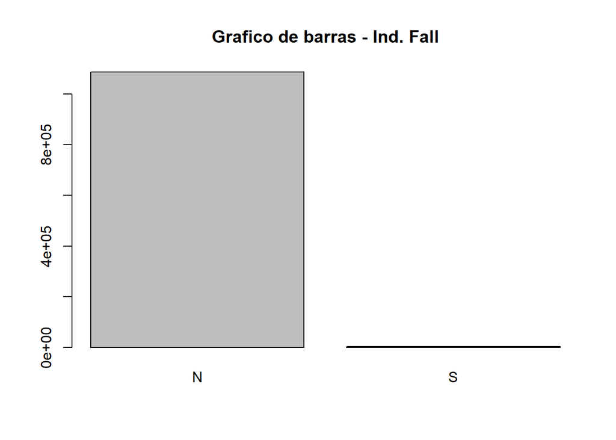

```r
counts <- table(df$indfall)
barplot(counts, main = "Grafico de barras - Ind. Fall")
```

En este caso ya que nos encontramos buscando productos para una campaña de productos, no nos interesan los clientes fallecidos (ademas representan menos del 1% porcentaje del total)

```r
#Seleccionamos aquellos clientes no fallecidos
df <- df[!(df$indfall == "S"),]
#Eliminamos la columna que no aporta informacion
drops <- c("indfall")
df <- df[, !(names(df) %in% drops)]
```

Con respecto a la variable *tipodom*, no aporta información ya que todos los registros son monovaluados.

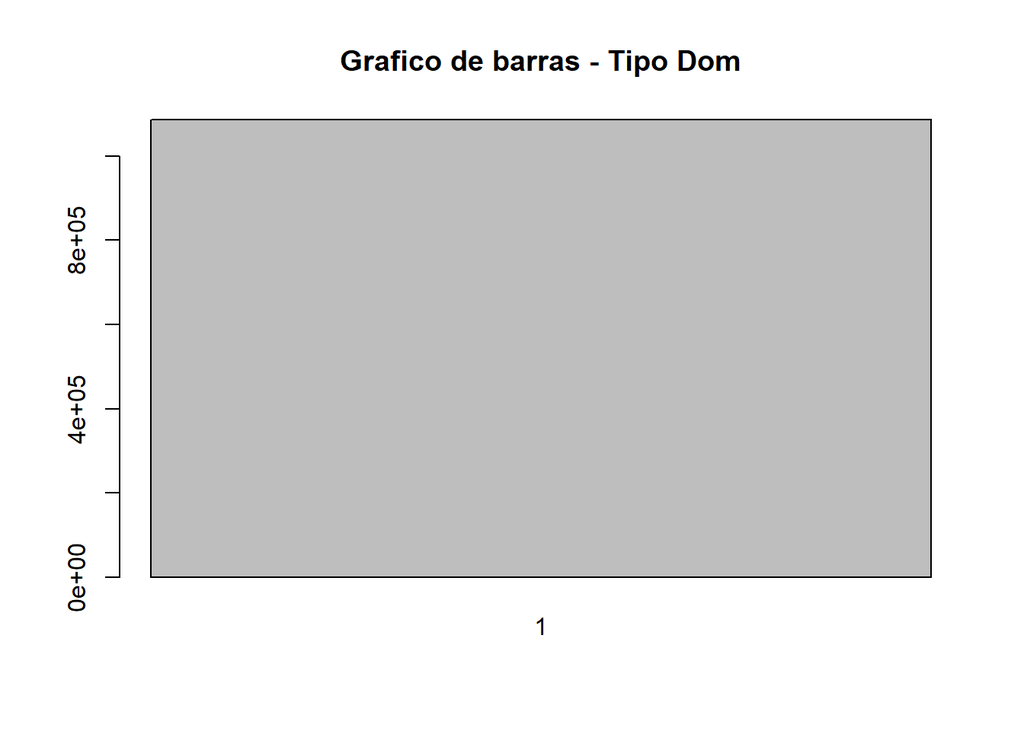

```r
counts <- table(df$tipodom)
barplot(counts, main = "Grafico de barras - Tipo Dom")
```

```r
drops <- c("tipodom")
df <- df[, !(names(df) %in% drops)]
```

```r
drops <- c("cod_prov")
df <- df[, !(names(df) %in% drops)]
df$nomprov <- mapvalues(df$nomprov, from=c(NA), to=c("D"))
```

Visualizamos los valores de *ind_actividad_cliente*, asignamos los valores nulos a 0 (no activo).

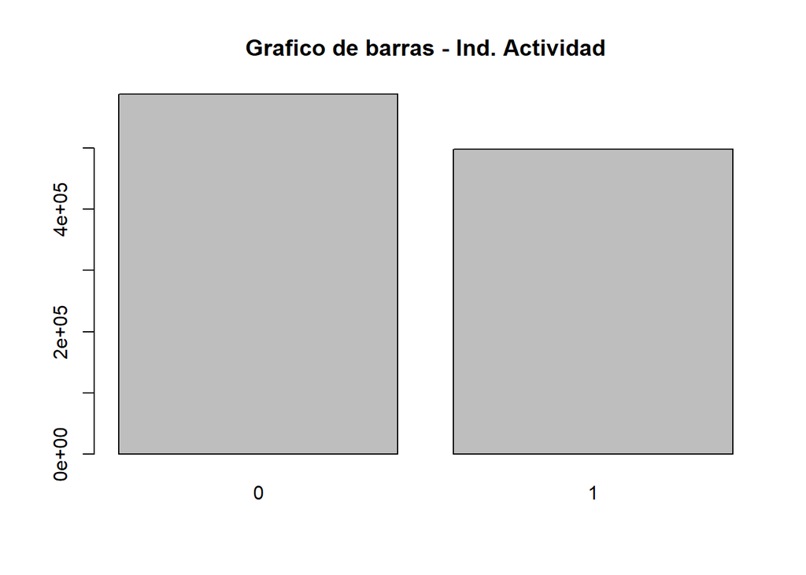

```r
counts <- table(df$ind_actividad_cliente)
barplot(counts, main = "Grafico de barras - Ind. Actividad")
```

```r
df$ind_actividad_cliente <- mapvalues(df$ind_actividad_cliente, from=c(NA), to=c(0))
```

Al contar con la variable antiguedad, y haber eliminado duplicados al inicio del analisis, podemos presindir de las variable *fecha_dato* y *fecha_alta*.

```r
drops <- c("fecha_dato", "fecha_alta")
df <- df[, !(names(df) %in% drops)]
```

Analizamos la variable *pais_residencia*

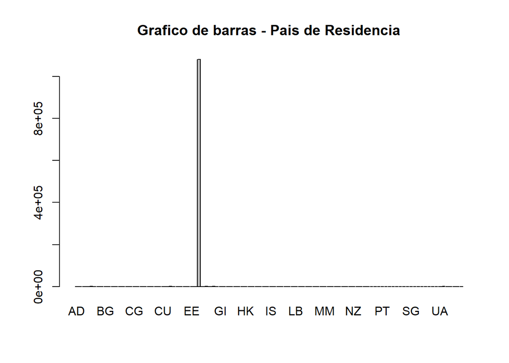

```r
counts <- table(df$pais_residencia)
barplot(counts, main = "Grafico de barras - Pais de Residencia")
```

Está conformada casi por completo en España, al contar con la variable provincia, la eliminamos.

```r
drops <- c("pais_residencia")
df <- df[, !(names(df) %in% drops)]
```

Ahora revisamos la variable *segmento*

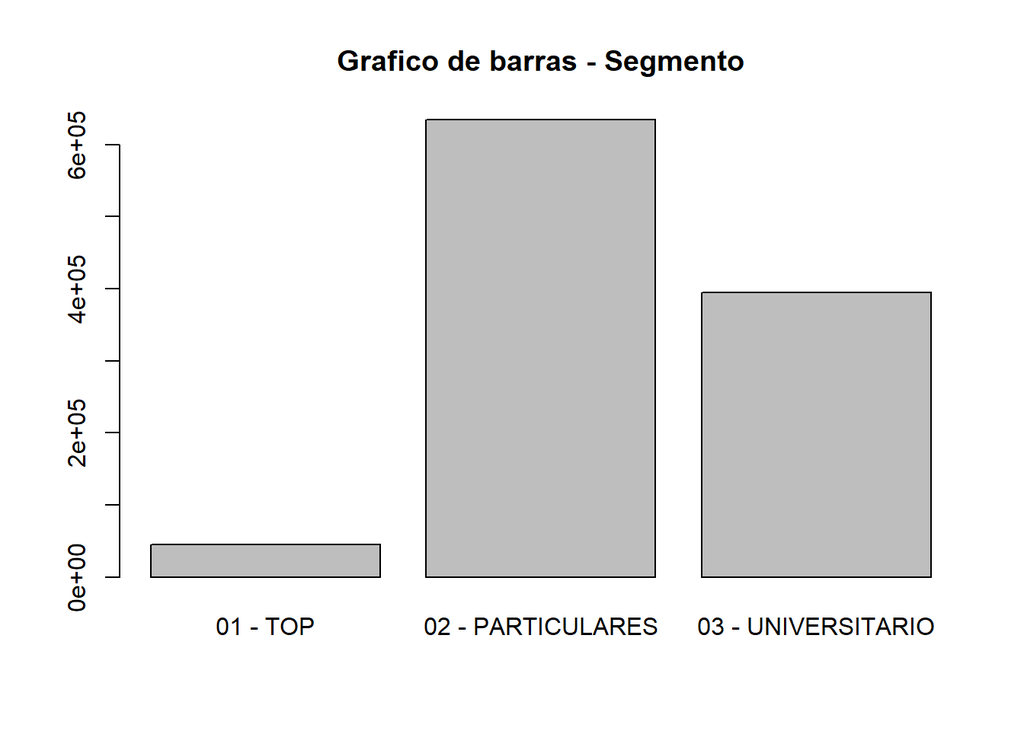

```r
counts <- table(df$segmento)
barplot(counts, main = "Grafico de barras - Segmento")
```

Indicamos los registros vacios con “D”

```r
df$segmento <- mapvalues(df$segmento, from=c(NA), to=c("D"))
```

Ahora revisamos la variable *canal_entrada*

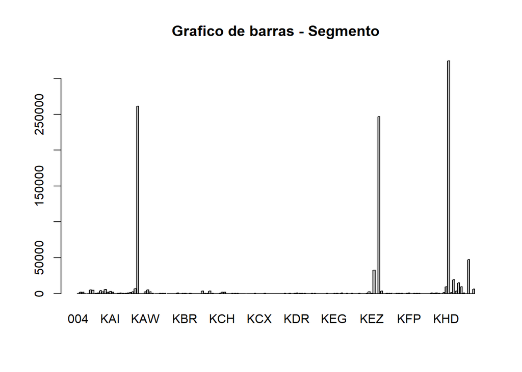

```r
counts <- table(df$canal_entrada)
barplot(counts, main = "Grafico de barras - Segmento")
```

Indicamos los registros vacios con “D”

```r
df$canal_entrada <- mapvalues(df$canal_entrada, from=c(NA), to=c("D"))
```

## 3.1 Tratamiento de outliers:

Primero realizaremos un grafico de caja de la variable *renta* para detectar outliers:

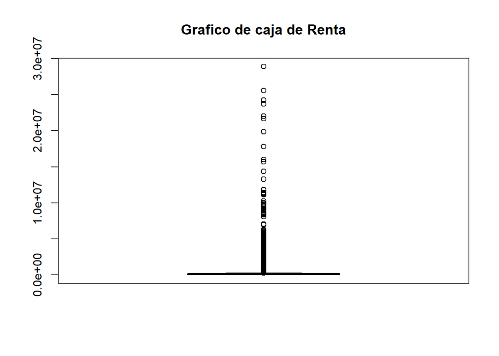

```r
boxplot(df$renta, main="Grafico de caja de Renta", col="gray")
```

Utilizaremos el principio de remoción de outliers basados en excluir aquellos fuera del rango intercuartilico: (asignaremos a NA)

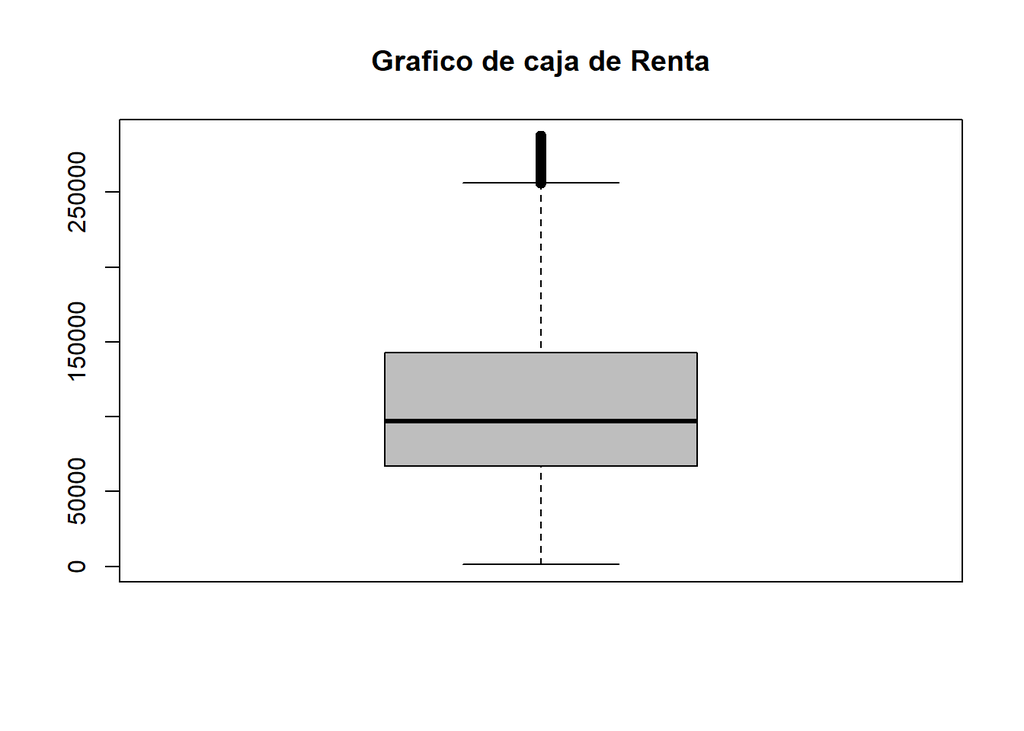

```r
df[df$renta %in% boxplot.stats(df$renta)$out, "renta"] <- NA
boxplot(df$renta, main="Grafico de caja de Renta", col="gray")
```

Seguidamente, imputamos los valores NA a la media del resto de datos:

```r
df$renta[is.na(df$renta)] <- mean(df$renta, na.rm = TRUE)
```

```r
head(df)
```

[output not shown]

# 4 Construcción de conjunto de datos final

Luego de realizar las correcciones verificamos los datos y exportamos como csv.

```r
df <- na.omit(df)
colMeans(is.na(df))
```

[output not shown]

```r
# escribimos el archivo csv
write.csv(df, "clean_data.csv", row.names = FALSE)
```